# ECE 5470 Lab 8 Report

## by Junjie Tian

```python
from v4 import vd
```

## 0. Keras Tutorial

The output when training the model in the Keras Turorial is as below: Epoch 1/12 469/469 ━━━━━━━━━━━━━━━━━━━━ 72s 149ms/step - accuracy: 0.1341 - loss: 2.2889 - val_accuracy: 0.4315 - val_loss: 2.2421 Epoch 2/12 469/469 ━━━━━━━━━━━━━━━━━━━━ 67s 143ms/step - accuracy: 0.2793 - loss: 2.2370 - val_accuracy: 0.5719 - val_loss: 2.1757 Epoch 3/12 469/469 ━━━━━━━━━━━━━━━━━━━━ 65s 138ms/step - accuracy: 0.3870 - loss: 2.1737 - val_accuracy: 0.6289 - val_loss: 2.0867 Epoch 4/12 469/469 ━━━━━━━━━━━━━━━━━━━━ 64s 137ms/step - accuracy: 0.4641 - loss: 2.0848 - val_accuracy: 0.6757 - val_loss: 1.9654 Epoch 5/12 469/469 ━━━━━━━━━━━━━━━━━━━━ 67s 142ms/step - accuracy: 0.5153 - loss: 1.9679 - val_accuracy: 0.7144 - val_loss: 1.8050 Epoch 6/12 469/469 ━━━━━━━━━━━━━━━━━━━━ 65s 137ms/step - accuracy: 0.5550 - loss: 1.8189 - val_accuracy: 0.7430 - val_loss: 1.6101 Epoch 7/12 469/469 ━━━━━━━━━━━━━━━━━━━━ 63s 133ms/step - accuracy: 0.5861 - loss: 1.6455 - val_accuracy: 0.7687 - val_loss: 1.3996 Epoch 8/12 469/469 ━━━━━━━━━━━━━━━━━━━━ 62s 132ms/step - accuracy: 0.6187 - loss: 1.4716 - val_accuracy: 0.7891 - val_loss: 1.2030 Epoch 9/12 469/469 ━━━━━━━━━━━━━━━━━━━━ 64s 135ms/step - accuracy: 0.6467 - loss: 1.3139 - val_accuracy: 0.8012 - val_loss: 1.0395 Epoch 10/12 469/469 ━━━━━━━━━━━━━━━━━━━━ 64s 137ms/step - accuracy: 0.6701 - loss: 1.1789 - val_accuracy: 0.8135 - val_loss: 0.9110 Epoch 11/12 469/469 ━━━━━━━━━━━━━━━━━━━━ 62s 133ms/step - accuracy: 0.6907 - loss: 1.0809 - val_accuracy: 0.8219 - val_loss: 0.8127 Epoch 12/12 469/469 ━━━━━━━━━━━━━━━━━━━━ 65s 138ms/step - accuracy: 0.7058 - loss: 0.9982 - val_accuracy: 0.8350 - val_loss: 0.7359 Test loss: 0.735905647277832 Test accuracy: 0.8349999785423279

## 1. Model evaluation

### Model K1

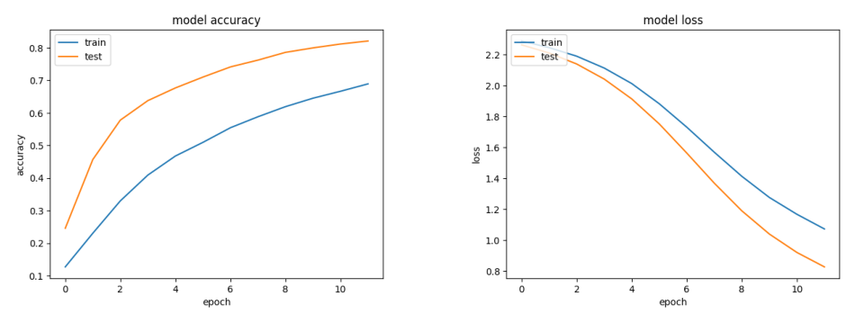

```
K1 Model Accuracy and Loss in Training
<scaled size: (455 x 567) (455 x 567) >
```

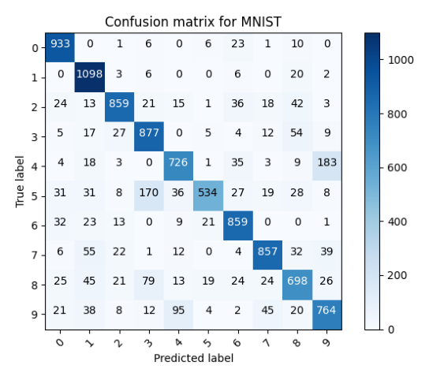

```
Confusion Matrix of K1 Model Testing
<scaled size: (470 x 534) >
```

```python
# Display the results of model K1
vd.dispmvx("K1_accuracy.png", "K1_loss.png", size=1.5, capt="K1 Model Accuracy and Loss in Training")
vd.dispmvx("K1_matrix.png", size=1.5, capt="Confusion Matrix of K1 Model Testing")
```

### Model K2

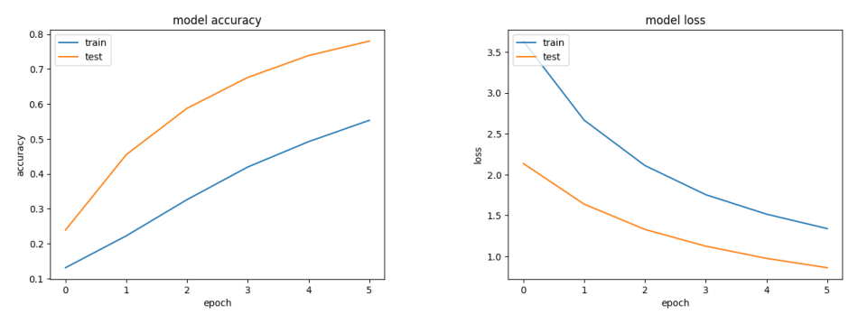

```
K2 Model Accuracy and Loss in Training
<scaled size: (455 x 567) (455 x 567) >
```

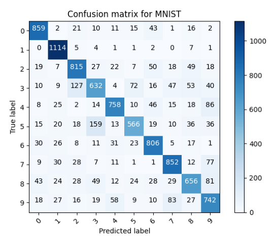

```
Confusion Matrix of K2 Model Testing
<scaled size: (470 x 534) >
```

```python
# Display the results of model K2
vd.dispmvx("K2_accuracy.png", "K2_loss.png", size=1.5, capt="K2 Model Accuracy and Loss in Training")
vd.dispmvx("K2_matrix.png", size=1.5, capt="Confusion Matrix of K2 Model Testing")
```

### Model P1

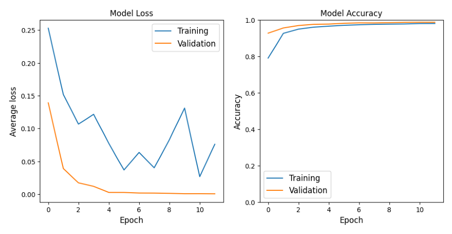

```
P1 Model Accuracy and Loss in Training
<scaled size: (474 x 936) >
```

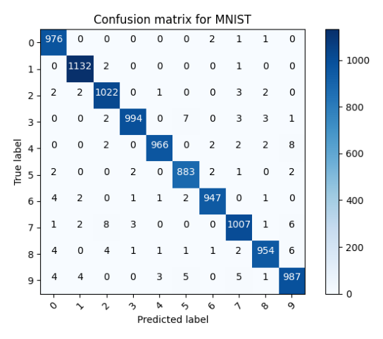

```
Confusion Matrix of P1 Model Testing
<scaled size: (470 x 534) >
```

```python
# Display the results of model P1
vd.dispmvx("P1_accuracy_loss.png", size=1.5, capt="P1 Model Accuracy and Loss in Training")
vd.dispmvx("P1_matrix.png", size=1.5, capt="Confusion Matrix of P1 Model Testing")
```

### Model P2

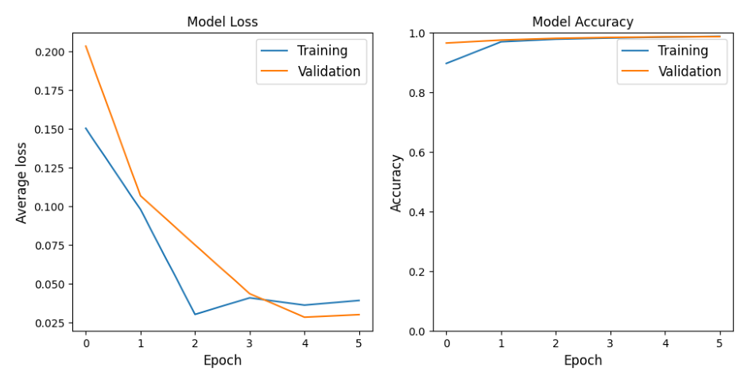

```
P2 Model Accuracy and Loss in Training
<scaled size: (474 x 945) >
```

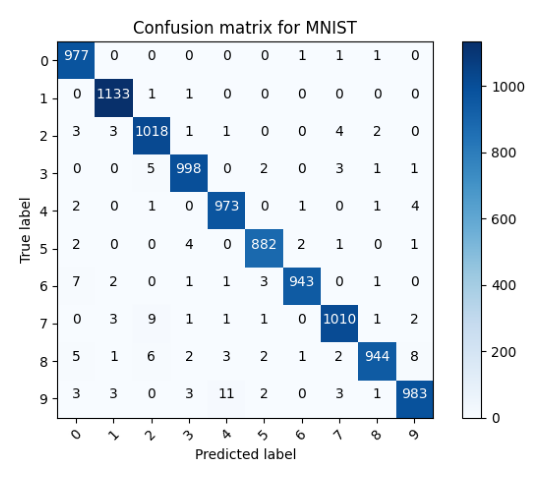

```
Confusion Matrix of P2 Model Testing
<scaled size: (470 x 534) >
```

```python
# Display the results of model P2
vd.dispmvx("P2_accuracy_loss.png", size=1.5, capt="P2 Model Accuracy and Loss in Training")
vd.dispmvx("P2_matrix.png", size=1.5, capt="Confusion Matrix of P2 Model Testing")
```

### Discussion:

1. About Keras and PyTorch: Keras abstracts away the computation backend, and we don't need to declare a lot of details when using this kind of model. PyTorch requires us to input explicit process in each stage, which gives us more flexibility but requires a longer execution time.
2. About the two models:
- Model 1 has more channels in the convolutional layers, has one more fully connected layer than Model 2, and has double number of epochs. Therefore, it is expected that Model 1 has higher computational cost than Model 2; K1 is expected to have longer running time than K2, and P1 is expected to have longer running time than P2. However, P1 runs faster than P2 maybe because I run P2 at the night of the original deadline, so a lot of people are using the server.
- Model 1 uses double number of epochs, so it is expected that the training and testing accuracy to be higher for Model 1. It is true for the Keras version, while the accuracy for the PyTorch version is similar. Maybe it's because the accuracy for the PyTorch model is already very high (more than 98%).
- They use different approaches to prevent the over-fitting problem. Model 1 has two rounds of dropouts, which introduces some randomness in training. Model 2 uses batch normalization to reduce the effect of strange or extreme values.
- Model 1 is more suitable for complex tasks and larger datasets, while Model 2 is more suitable for simpler tasks and smaller datasets.

## 2. New Model Design

```python
# The new model is included in a separate file 'lab8part4.ipynb'
```

### Changes of the Model

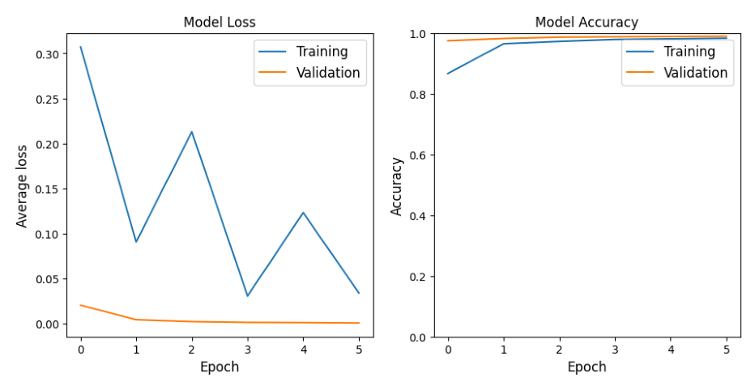

```
Custom Model Accuracy and Loss in Training
<scaled size: (474 x 936) >
```

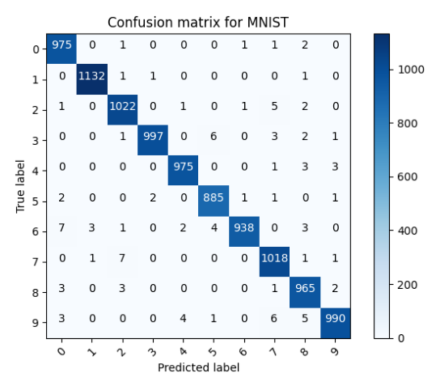

```
Confusion Matrix of Custom Model Testing
<scaled size: (470 x 534) >
```

```python
# Display the results of the custom model
vd.dispmvx("custom_accuracy_loss.png", size=1.5, capt="Custom Model Accuracy and Loss in Training")
vd.dispmvx("custom_matrix.png", size=1.5, capt="Confusion Matrix of Custom Model Testing")
```

## 3. Results on own Data

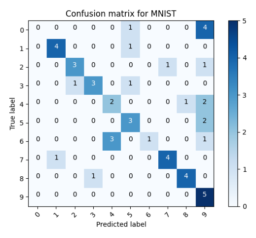

```
Confusion Matrix of Model P2 Testing with Own Dataset
<scaled size: (470 x 508) >
```

```python
# Display the results of the custom model
vd.dispmvx("own_matrix.png", size=1.5, capt="Confusion Matrix of Model P2 Testing with Own Dataset")
```

Discussion: The testing accuracy is way lower then the testing accuracy using the MNIST dataset, because I have different writing styles as the numbers used for training. In the dataset, the numbers are wider and take up more spaces; however, I write numbers in a more vertical and thinner way than in the dataset. Therefore, the accuracy is low, especially for number 0, 4, and 6, which I wrote way thinner than the numbers in the dataset.

## 4. Summary

### Comparison of approaches

[output not shown]

### Discusssion

#### 1. The Keras models generally have shorter training time and lower accuracy than the PyTorch models. The reason maybe that Keras abstracts away the computation backend, and we don't need to declare a lot of details when using this kind of model. PyTorch requires us to input explicit process in each stage, which gives us more flexibility but requires a longer execution time.

#### 2. The number of tasks running on the server can affect the efficiency of training very much. For instance, I run Model P1 and P2 at nights of the original deadline, and I run the Custom Model during the night before the Thanksgiving break, so the training time is way less for the Custom Model. However, such a difference is not expected if I train these models at the same period.

#### 3. We should try to maintain the writing styles, light conditions, sizes, and all environmental parameters as similar as possible between the training datasets and the test datasets, so that the testing accuracy can accurately reflect the performance of the model. In my custom data, the writing styles of me are way different from the writing style of data in the MNIST datasets, and the accuracy doesn't reflect the performance of the model accurately.